# Mapping Fatal Police Encounters in the US

- Show All Code
- Hide All Code
- View Source

Author

Santiago Giordano

## Visualization

Is there any evidence of geographical or political trends? Where do we see the highest, and lowest, rates of fatal police encounters?

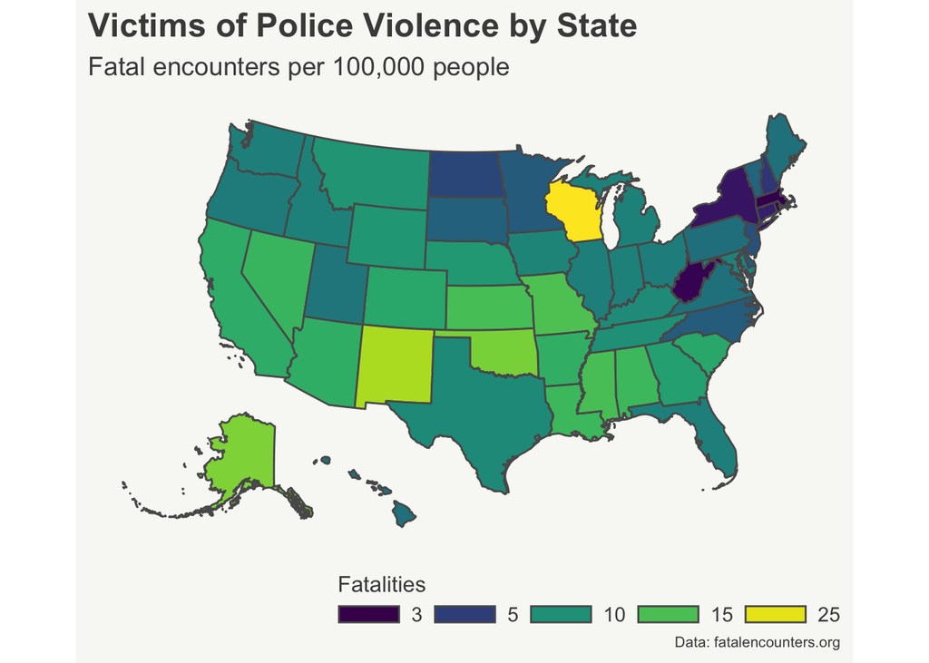

- Higher rates of police fatal encounters are found predominantly in sun belt states. A possible explanation for this trend is the weather: people are more likely to be outside in areas with warmer climates, which in turn increases the probabilities they’ll have an encounter with the police. The exception to this trend is the state of Wisconsin, which actually has the highest rate of fatal police encounters with 25 fatalities per 100,000 people (as a reference, the national average is about 10 fatalities). When considering the social unrest that the state experienced after George Floyd’s murder Wisconsin’s fatal police encounters are not necessarily a surprise; nevertheless, we cannot determine what the main drivers are for these numbers in the state from this superficial graphical analysis.
- The lowest fatality rates are primarily concentrated in Northeastern states - these numbers are no surprise either as the Northeast is a region characterized by having some of the strictest gun regulations in the country.
- Conversely, a surprising find is we do not seem to find evidence of an association between fatal encounter rates and political divides. In other words, we don’t see any clear trends among blue or red states for higher or lower fatality rates.

## Data

#### Packages used:

```r
library(pacman)
p_load(dplyr, magrittr, broom, ggplot2, sf, tidyverse, maps, mapdata,
       hrbrthemes, ggthemes, rnaturalearth, urbnmapr)
```

#### Load data

The raw data is sourced from the Fatal Encounters database. Each observation in the data represents one death caused by a police intervention or use of force, and it includes variables for demographic and geographic characteristics of each incidence, as well as some descriptive variables. Additionally, I use the geospatial data for US states provided by the `urbnmapr` package.

```r
# Load Data
  # Fatal encounters data
fatal_encounters <- read.csv(
  here::here("Data", "Fatal_Encounters.nosync.csv"))
  # Geospatial data for US states
usa_states <- get_urbn_map("states", sf = TRUE)
```

#### Some data wrangling

I aggregated the observations in the raw data by state to find the number of fatal police encounters in each state. Then I adjusted the aggregated data for population to generate fatal encounters for every 100,000 inhabitants in order to do proportional comparisons.

```r
## Some data wrangling:

# Summarize number of fatal encounters by state
encs_by_state <- fatal_encounters %>%
                      group_by(State) %>%
                      summarise(n_fatalencs = n())
# Get rid of first row
encs_by_state <- encs_by_state[-c(1), ]

# Add column with population for each state
encs_by_state$state_pop <- c(700000, 5000000, 3000000, 7100000, 39500000, 5700000,
                             3600000, 700000, 1000000, 21500000, 10700000, 1500000,
                             3200000, 1800000, 12800000, 6800000, 2900000, 4500000,
                             4700000, 7000000, 6200000, 1400000, 10100000, 5700000,
                             6200000, 3000000, 1100000, 10400000, 800000, 2000000,
                             1400000, 9300000, 2100000, 3100000, 20200000, 11800000,
                             4000000, 4200000, 13000000, 1100000, 5100000, 900000,
                             6900000, 29100000, 3300000, 8600000, 600000, 7700000,
                             1800000, 5900000, 600000)

# Calculate fatal encounters per 100,000 people
encs_by_state %<>% mutate(
    fatalencs_per_100k = (n_fatalencs / state_pop) * 100000)

# Print dataset created
head(encs_by_state, 5)
## # A tibble: 5 × 4
##   State n_fatalencs state_pop fatalencs_per_100k
##   <chr>       <int>     <dbl>              <dbl>
## 1 AK            129    700000               18.4
## 2 AL            700   5000000               14
## 3 AR            391   3000000               13.0
## 4 AZ            914   7100000               12.9
## 5 CA           4969  39500000               12.6
```

#### Set up final dataframe for plotting

Finally, I merge this aggregated data with the geospatial data for US states.

```r
# Set up final dataframe for plotting

# Join data for number of fatal encounters by state data with geospatial data of US state
encs_by_state_geoms <- merge(encs_by_state, usa_states,
                             by.x = "State", by.y = "state_abbv")

# Convert new dataframe into an sf object
spatial_fatalencs <- st_as_sf(encs_by_state_geoms) #%>% st_transform(8857)
```

## Source

Data from fatalencounters.org